# Solution of an AM9561 Final Exam Problem

## From 2010

### A guest lecture by Rob Corless

2024-12-02

The exam took place in a room where examinees had access to computers, which were locked down so they could use MATLAB and Maple, but only those two programs. All the help facilities were available.

It was a stressful time, but everyone passed. They did well, in fact.

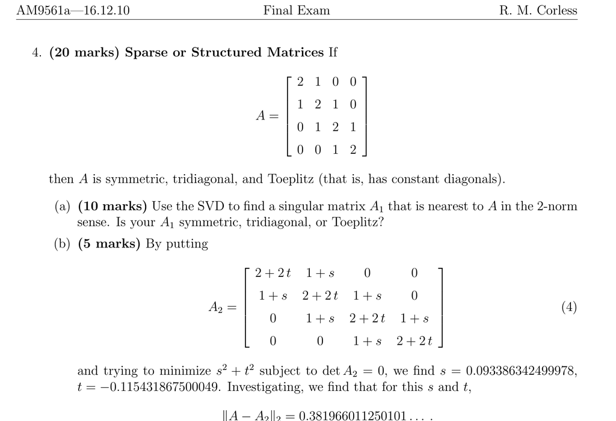

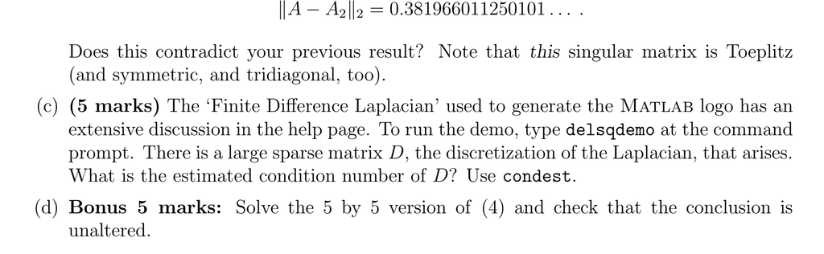

```python
N := 4;
A := Matrix(N, N, (i, j) -> `if`(i = j, 2,
            `if`(abs(i - j) = 1, 1, 0)), shape = symmetric);
```

```
                                    N := 4
```

$$\left[\begin{array}{cccc} 2 & 1 & 0 & 0 \\ 1 & 2 & 1 & 0 \\ 0 & 1 & 2 & 1 \\ 0 & 0 & 1 & 2 \end{array}\right]$$

Actually we know what the singular values of this symmetric Toeplitz matrix are. P. 304 of Corless and Fillion has that the eigenvalues are $\lambda = b + 2 \sqrt{ac}\cos( k\pi/(N+1) )$ for $1 \le k \le N$. The proof uses Chebyshev polynomials of the second kind, U(n,x). And since for positive definite symmetric matrices, singular values are the eigenvalues, we are done. The smallest is

```python
smallest := 2 - 2*cos(Pi/(N + 1));
```

$$2-2 \cos \left(\frac{\pi}{5}\right)$$

```python
evalf(smallest);
```

$$ 0.38196601125010$$

But let's do it numerically anyway. For the minimization problem later, it turns out that we need high precision (when N=13).

```python
Digits := 60;
with(LinearAlgebra):
U, S, Vt := SingularValues(evalf(A), output = ['U', 'S', 'Vt']);
```

```
                                 Digits := 60
```

$$\left[\begin{array}{cccc} - 0.371748034460184490132060189463344931012525094933200191988497 & 0.601500955007545673655997558844807649728516032218709918413868 & - 0.601500955007545673655997558844807649728516032218709918413870 & - 0.371748034460184490132060189463344931012525094933200191988484 \\ - 0.601500955007545673655997558844807649728516032218709918413881 & 0.371748034460184490132060189463344931012525094933200191988472 & 0.371748034460184490132060189463344931012525094933200191988487 & 0.601500955007545673655997558844807649728516032218709918413873 \\ - 0.601500955007545673655997558844807649728516032218709918413869 & - 0.371748034460184490132060189463344931012525094933200191988498 & 0.371748034460184490132060189463344931012525094933200191988474 & - 0.601500955007545673655997558844807649728516032218709918413880 \\ - 0.371748034460184490132060189463344931012525094933200191988473 & - 0.601500955007545673655997558844807649728516032218709918413884 & - 0.601500955007545673655997558844807649728516032218709918413876 & 0.371748034460184490132060189463344931012525094933200191988481 \end{array}\right],\left[\begin{array}{c} 3.61803398874989484820458683436563811772030917980576286213548 \\ 2.61803398874989484820458683436563811772030917980576286213547 \\ 1.38196601125010515179541316563436188227969082019423713786458 \\ 0.381966011250105151795413165634361882279690820194237137864552 \end{array}\right],\left[\begin{array}{cccc} - 0.371748034460184490132060189463344931012525094933200191988497 & - 0.601500955007545673655997558844807649728516032218709918413879 & - 0.601500955007545673655997558844807649728516032218709918413869 & - 0.371748034460184490132060189463344931012525094933200191988472 \\ 0.601500955007545673655997558844807649728516032218709918413872 & 0.371748034460184490132060189463344931012525094933200191988468 & - 0.371748034460184490132060189463344931012525094933200191988498 & - 0.601500955007545673655997558844807649728516032218709918413885 \\ - 0.601500955007545673655997558844807649728516032218709918413873 & 0.371748034460184490132060189463344931012525094933200191988481 & 0.371748034460184490132060189463344931012525094933200191988486 & - 0.601500955007545673655997558844807649728516032218709918413880 \\ - 0.371748034460184490132060189463344931012525094933200191988484 & 0.601500955007545673655997558844807649728516032218709918413872 & - 0.601500955007545673655997558844807649728516032218709918413873 & 0.371748034460184490132060189463344931012525094933200191988479 \end{array}\right]$$

```python
S[N];
```

$$ 0.381966011250105151795413165634361882279690820194237137864552$$

```python
smallest;
```

$$2-2 \cos \left(\frac{\pi}{5}\right)$$

```python
evalf(S[N]-smallest);
```

$$ 0.0$$

Erhard Schmidt's theorem (though Eckart, Young, and Mirsky get the credit) says set the smallest singular value to zero, and that will give you a "nearest singular matrix".

```python
Sigma := Matrix(N, N, (i, j) -> `if`(i = j, S[i], 0));
```

$$\left[\begin{array}{cccc} 3.61803398874989484820458683436563811772030917980576286213548 & 0 & 0 & 0 \\ 0 & 2.61803398874989484820458683436563811772030917980576286213547 & 0 & 0 \\ 0 & 0 & 1.38196601125010515179541316563436188227969082019423713786458 & 0 \\ 0 & 0 & 0 & 0.381966011250105151795413165634361882279690820194237137864552 \end{array}\right]$$

```python
Sigma[N,N] := 0:
Ahat := U.Sigma.Vt:
Norm( A-Ahat, 2 );
```

$$ 0.381966011250105151795413165634361882279690820194237137864543$$

```python
hatS := SingularValues(Ahat):
```

```python
hatS[N];
```

$$ 0.0$$

```python
Norm( Ahat - Transpose(Ahat), infinity );
```

$${ 2.6\times 10^{-59}}$$

On to the next part. This has to do with *Siegfried Rump's Theorem* which identifies classes of matrices where the *structured* nearest singular matrix has the same distance as the unstructured nearest singular matrix.

```python
A2 := Matrix(N, N, (i, j) -> `if`(i = j, 2 + 2*t,
  `if`(abs(i - j) = 1, 1 + s, 0)), shape = symmetric);
```

$$\left[\begin{array}{cccc} 2+2 t & 1+s & 0 & 0 \\ 1+s & 2+2 t & 1+s & 0 \\ 0 & 1+s & 2+2 t & 1+s \\ 0 & 0 & 1+s & 2+2 t \end{array}\right]$$

```python
constraint := Determinant(A2);
```

$$s^{4}-12 s^{2} t^{2}+16 t^{4}+4 s^{3}-24 s^{2} t -24 s \,t^{2}+64 t^{3}-6 s^{2}-48 s t +84 t^{2}-20 s +40 t +5$$

We want to minimize s and t such that the determinant of A2 is zero.

How do we do this?

Lagrange multipliers ring a bell?

(In which undergraduate year are Lagrange multipliers taught nowadays, if they are taught?)

(And who remembers what they were taught years ago and never use again??)

```python
F := s^2 + t^2 + lambda*constraint;
```

$$\lambda \left(s^{4}-12 s^{2} t^{2}+16 t^{4}+4 s^{3}-24 s^{2} t -24 s \,t^{2}+64 t^{3}-6 s^{2}-48 s t +84 t^{2}-20 s +40 t +5\right)+s^{2}+t^{2}$$

```python
eqs := [diff(F,s), diff(F,t), diff(F,lambda)]:
```

How do we solve multivariate polynomial equations? ($s$, $t$, $\lambda$)

Groebner bases to the rescue (with a little help from eigenvectors)

```python
gb := Groebner:-Basis(eqs, tdeg(s, t, lambda)):
numelems(gb);
```

$$6$$

Normal Sets and Multiplication Matrices are not part of the normal education

(maybe they should be)

```python
ns, rv := Groebner:-NormalSet(gb, tdeg(s, t, lambda)):
Ms := Groebner:-MultiplicationMatrix(s, ns, rv, gb, tdeg(s, t, lambda));
```

$$\left[\begin{array}{cccc} 0 & 0 & 0 & 1 \\ \frac{83297}{494960} & -\frac{5363}{6187} & -\frac{104661}{2474800} & -\frac{4278631}{2474800} \\ \frac{5}{58} & 0 & \frac{1}{58} & -\frac{59}{58} \\ \frac{11435}{1076538} & -\frac{3200}{538269} & -\frac{27975}{358846} & -\frac{41605}{358846} \end{array}\right]$$

```python
Mt := Groebner:-MultiplicationMatrix(t, ns, rv, gb, tdeg(s, t, lambda));
```

$$\left[\begin{array}{cccc} 0 & 0 & 1 & 0 \\ \frac{12653}{494960} & -\frac{6776}{6187} & \frac{376391}{2474800} & \frac{104661}{2474800} \\ -\frac{11435}{1076538} & \frac{3200}{538269} & -\frac{330871}{358846} & -\frac{317241}{358846} \\ \frac{5}{58} & 0 & \frac{1}{58} & -\frac{59}{58} \end{array}\right]$$

```python
ML := Groebner:-MultiplicationMatrix(lambda, ns, rv, gb, tdeg(s, t, lambda));
```

$$\left[\begin{array}{cccc} 0 & 1 & 0 & 0 \\ \frac{9749852369}{395968000} & -\frac{14703902}{154675} & -\frac{59166564237}{1979840000} & -\frac{570551952627}{1979840000} \\ \frac{12653}{494960} & -\frac{6776}{6187} & \frac{376391}{2474800} & \frac{104661}{2474800} \\ \frac{83297}{494960} & -\frac{5363}{6187} & -\frac{104661}{2474800} & -\frac{4278631}{2474800} \end{array}\right]$$

These matrices commute with each other.

```python
(Ms . Mt) - (Mt . Ms);
```

$$\left[\begin{array}{cccc} 0 & 0 & 0 & 0 \\ 0 & 0 & 0 & 0 \\ 0 & 0 & 0 & 0 \\ 0 & 0 & 0 & 0 \end{array}\right]$$

```python
(ML . Mt) - (Mt . ML);
```

$$\left[\begin{array}{cccc} 0 & 0 & 0 & 0 \\ 0 & 0 & 0 & 0 \\ 0 & 0 & 0 & 0 \\ 0 & 0 & 0 & 0 \end{array}\right]$$

That means we share eigenvectors. Not only that, they are the shape of the Normal Set (computed above):

```python
ns;
```

| 1 | lambda | t | s |
| --- | --- | --- | --- |

```python
alf := rand()/0.1e13:
bet := rand()/0.1e13:
M := alf*Ms + bet*Mt + (1 - alf - bet)*ML
```

[output not shown]

```python
(E, V) := Eigenvectors(M, output = ['values', 'vectors']):
for k to N do
    if ns[k] = s then
        sindx := k;
    end if;
    if ns[k] = t then
        tindx := k;
    end if;
    if ns[k] = lambda then
        lambdaindx := k;
    end if;
end do:
```

```python
[sindx,tindx,lambdaindx];
```

| 4 | 3 | 2 |
| --- | --- | --- |

```python
small := infinity:
for k to N do
    v := V[1 .. -1, k]/V[1, k];
    ess := v[sindx];
    tea := v[tindx];
    if ess^2 + tea^2 < small then
        Ess := ess;
        Tea := tea;
        Lamb := v[lambdaindx];
        small := ess^2 + tea^2;
    end if;
end do:
```

```python
evalf[5]([Ess, Tea]);
```

| .93386e-1+0.*I | -.11543-0.*I |
| --- | --- |

```python
eval(constraint, [s = Ess, t = Tea]);
```

$$-{ 1.99\times 10^{-57}}+ 0.0 \mathrm{I} $$

```python
evalf[5]( eval(A2, [s = Ess, t = Tea]) );
```

$$\left[\begin{array}{cccc} 1.7691- 0.0 \,\mathrm{I} & 1.0934+ 0.0 \,\mathrm{I} & 0.0 & 0.0 \\ 1.0934+ 0.0 \,\mathrm{I} & 1.7691- 0.0 \,\mathrm{I} & 1.0934+ 0.0 \,\mathrm{I} & 0.0 \\ 0.0 & 1.0934+ 0.0 \,\mathrm{I} & 1.7691- 0.0 \,\mathrm{I} & 1.0934+ 0.0 \,\mathrm{I} \\ 0.0 & 0.0 & 1.0934+ 0.0 \,\mathrm{I} & 1.7691- 0.0 \,\mathrm{I} \end{array}\right]$$

```python
ACT := eval(A2, [s = Ess, t = Tea]):
SACT := SingularValues(ACT);
```

$$\left[\begin{array}{c} 3.53827252999979694825713319739571498594266600238354207860620 \\ 2.44488618749981870380101178338903123744880893069959114161267 \\ 1.09338634249997824445612141400668374849385707168395093699335 \\ 2.16075550820898358459014672172676847777702037853910543171283\times \\ 10^{-58} \end{array}\right]$$

```python
S[1];
```

$$ 3.61803398874989484820458683436563811772030917980576286213548$$

```python
Norm( A - ACT, 2 );
```

$$ 0.381966011250105151795413165634361882279690820194237137864758$$

```python
evalf( smallest );
```

$$ 0.38196601125010515179541316563436188227969082019423713786455$$

Aha. ACT is symmetric, *Toeplitz*, singular, and just as near to $A$ as $\hat{A}$ was. This does not contradict Schmidt's theorem, which just says the minimum occurs when you put the smallest singular value to zero.

But there can be *other* matrices where the minimum occurs, too.

```python
N := 'N':
s := -cos(Pi/(N + 1))*(cos(Pi/(N + 1)) - 1)/(cos(Pi/(N + 1))^2 + 1);
```

$$-\frac{\cos \left(\frac{\pi}{N +1}\right) \left(\cos \left(\frac{\pi}{N +1}\right)-1\right)}{\cos \left(\frac{\pi}{N +1}\right)^{2}+1}$$

```python
t := (cos(Pi/(N + 1)) - 1)/(cos(Pi/(N + 1))^2 + 1);
```

$$\frac{\cos \left(\frac{\pi}{N +1}\right)-1}{\cos \left(\frac{\pi}{N +1}\right)^{2}+1}$$

```python
minsqd := simplify( s^2 + t^2 );
```

$$\frac{\left(\cos \left(\frac{\pi}{N +1}\right)-1\right)^{2}}{\cos \left(\frac{\pi}{N +1}\right)^{2}+1}$$

```python
evalf[5]( sqrt( eval( minsqd, N=4 )));
```

$$ 0.14847$$